# Machine Learning

SP

Saturday, January 24, 2015

This project analyzes the Weight Lifting Exercises Dataset available at http://groupware.les.inf.puc-rio.br/har#weight_lifting_exercises. The goal is to study effectiveness of exercise based on data from human activity recognition devices. We take the training data set, run through a basic exploratory data analysis, data clean up, pre-processing before positioning to run using machine learning algorithms.

**Load and explore**

```r
require(corrplot)
require(caret)
require(lubridate)
training=read.csv("pml-training.csv", header=TRUE)
test = read.csv("pml-testing.csv", header=TRUE)
head(str(training))
```

```
## 'data.frame':    19622 obs. of  160 variables:
##  $ X                       : int  1 2 3 4 5 6 7 8 9 10 ...
##  $ user_name               : Factor w/ 6 levels "adelmo","carlitos",..: 2 2 2 2 2 2 2 2 2 2 ...
##  $ raw_timestamp_part_1    : int  1323084231 1323084231 1323084231 1323084232 1323084232 1323084232 1323084232 1323084232 1323084232 1323084232 ...
##  $ raw_timestamp_part_2    : int  788290 808298 820366 120339 196328 304277 368296 440390 484323 484434 ...
##  $ cvtd_timestamp          : Factor w/ 20 levels "02/12/2011 13:32",..: 9 9 9 9 9 9 9 9 9 9 ...
##  $ new_window              : Factor w/ 2 levels "no","yes": 1 1 1 1 1 1 1 1 1 1 ...
##  $ num_window              : int  11 11 11 12 12 12 12 12 12 12 ...
##  $ roll_belt               : num  1.41 1.41 1.42 1.48 1.48 1.45 1.42 1.42 1.43 1.45 ...
##  $ pitch_belt              : num  8.07 8.07 8.07 8.05 8.07 8.06 8.09 8.13 8.16 8.17 ...
##  $ yaw_belt                : num  -94.4 -94.4 -94.4 -94.4 -94.4 -94.4 -94.4 -94.4 -94.4 -94.4 ...
##  $ total_accel_belt        : int  3 3 3 3 3 3 3 3 3 3 ...
##  $ kurtosis_roll_belt      : Factor w/ 397 levels "","-0.016850",..: 1 1 1 1 1 1 1 1 1 1 ...
##  $ kurtosis_picth_belt     : Factor w/ 317 levels "","-0.021887",..: 1 1 1 1 1 1 1 1 1 1 ...
##  $ kurtosis_yaw_belt       : Factor w/ 2 levels "","#DIV/0!": 1 1 1 1 1 1 1 1 1 1 ...
```

[output cut: 86 more lines]

With several variables having NAs, we need to trim the variables down first to what probably matters most.

After some analysis of this dataset, i make a few assumptions and conclusions: 1. It suffices to use hour of the day exercised on not the exact time 2. Who did the exercise is less important to study how well exercise is done and predict for other test sets. So, i drop user_name 3. Most of the min, max, avg, stddev, kurtosis, skewness, var columns are derived statistical measures. I would choose to keep the “raw” fields 4. Get rid of all columns with too many NAs or having very low variance 5. Check on the correlation matrix of those numeric columns as a sanity check and see if some may be dropped

```r
set.seed(1234)
training$raw_timestamp_part_1 = NULL; training$raw_timestamp_part_2 = NULL; training$X = NULL ;
training$user_name = NULL
training$cvtd_timestamp = strptime(training$cvtd_timestamp, '%d/%m/%Y %H:%M')
training$cvtd_timestamp = hour(training$cvtd_timestamp)
training$cvtd_timestamp = as.factor(training$cvtd_timestamp)
training=training[-grep('min', names(training))]
training=training[-grep('max', names(training))]
training=training[-grep('avg', names(training))]
training=training[-grep('stddev', names(training))]
training=training[-grep('var', names(training))]
training=training[-grep('amplitude', names(training))]
training=training[-grep('kurtosis', names(training))]
training=training[-grep('skewness', names(training))]
nzvar = nearZeroVar(training)
training = training[, -nzvar]
```

**Checking correlations**

Lets check a correlation matrix plot on the numerics of interest

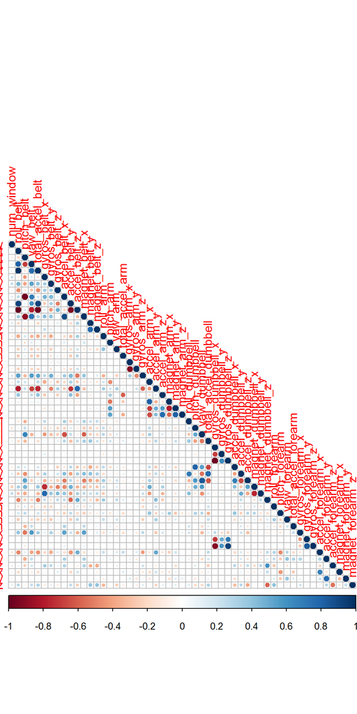

```r
trainCor = training[, sapply(training, is.numeric)]
corrplot(cor(trainCor), type="lower")
```

We may check which of the predictors are well correlated for later verifications post machine learning run.

```r
M <- abs(cor(trainCor))
which(M > 0.8, arr.ind=TRUE)
```

```
##                      row col
## num_window             1   1
## roll_belt              2   2
## yaw_belt               4   2
## total_accel_belt       5   2
## accel_belt_y          10   2
## accel_belt_z          11   2
## pitch_belt             3   3
## accel_belt_x           9   3
## magnet_belt_x         12   3
## roll_belt              2   4
## yaw_belt               4   4
## roll_belt              2   5
## total_accel_belt       5   5
## accel_belt_y          10   5
## accel_belt_z          11   5
## gyros_belt_x           6   6
## gyros_belt_y           7   7
## gyros_belt_z           8   8
## pitch_belt             3   9
## accel_belt_x           9   9
## magnet_belt_x         12   9
## roll_belt              2  10
## total_accel_belt       5  10
## accel_belt_y          10  10
## accel_belt_z          11  10
## roll_belt              2  11
## total_accel_belt       5  11
## accel_belt_y          10  11
## accel_belt_z          11  11
## pitch_belt             3  12
## accel_belt_x           9  12
## magnet_belt_x         12  12
## magnet_belt_y         13  13
## magnet_belt_z         14  14
## roll_arm              15  15
## pitch_arm             16  16
## yaw_arm               17  17
## total_accel_arm       18  18
## gyros_arm_x           19  19
```

[output cut: 37 more lines]

```
## yaw_forearm           43  43
## total_accel_forearm   44  44
## gyros_forearm_x       45  45
## gyros_forearm_y       46  46
## gyros_forearm_z       47  46
## gyros_dumbbell_x      32  47
## gyros_dumbbell_z      34  47
## gyros_forearm_y       46  47
## gyros_forearm_z       47  47
## accel_forearm_x       48  48
## accel_forearm_y       49  49
## accel_forearm_z       50  50
## magnet_forearm_x      51  51
## magnet_forearm_y      52  52
## magnet_forearm_z      53  53
```

```r
nrow(which(M > 0.8, arr.ind=T))
```

```
## [1] 91
```

By this time, we have eliminated and reduced the dataset to only those predictors that have reasonable say on the outcome.

**Prediction Model**

I am choosing random forest in the caret package to train and test on the data provided.

Random forest specifically for its ability to deliver accurate predictions and on large data sets with multiple variablees. We have 50+ at hand on several thousand rows to learn from. I used a 10 fold cross validation passed to the train control parameter as below for the random forest run. It took too long and so i cut it to 5 and rerun as shown here.

The reason i am choosing to pick Random Forest is that test data set is not really needed given the nature of that algorithm. Every classification tree planted sets aside 33% of the data set in the sample space for test and preparation of the vote and finally the votes of classifications are looked at by the finalizer to arrive pick the best model. Secondly, considering the clean up, pre-processing we already did, we have a good chance of coming up with an accurate model. Once built, i use this model against the test data set for validation.

I have tried running it outside of RMD and it takes quite a bit of time. Ideall, i would like to pass trControl and grid parameters with more values, but i may never shut my poor laptop down. So, i stay with this one run (which has to be re-run just to create the HTML)

```r
fit <-train(classe~.,data=training,method="rf", trControl=trainControl(method="cv",number=5),prox=TRUE,allowParallel=TRUE)
print(fit$finalModel)
```

```
##
## Call:
##  randomForest(x = x, y = y, mtry = param$mtry, proximity = TRUE,      allowParallel = TRUE)
##                Type of random forest: classification
##                      Number of trees: 500
## No. of variables tried at each split: 29
##
##         OOB estimate of  error rate: 0.14%
## Confusion matrix:
##      A    B    C    D    E  class.error
## A 5578    2    0    0    0 0.0003584229
## B    6 3788    3    0    0 0.0023702923
## C    0    4 3418    0    0 0.0011689071
## D    0    0    9 3206    1 0.0031094527
## E    0    0    0    3 3604 0.0008317161
```

```r
importance(fit$finalModel)
```

```
##                      MeanDecreaseGini
## cvtd_timestamp13             2.306718
## cvtd_timestamp14            27.360384
## cvtd_timestamp17            11.020426
## num_window                2878.633334
## roll_belt                 1846.640290
## pitch_belt                 813.398982
## yaw_belt                   928.389820
## total_accel_belt            78.698086
## gyros_belt_x                43.589566
## gyros_belt_y                50.280164
## gyros_belt_z               154.410827
## accel_belt_x                39.693756
## accel_belt_y                56.939455
## accel_belt_z               285.179573
## magnet_belt_x              170.104197
## magnet_belt_y              197.181594
## magnet_belt_z              216.567907
## roll_arm                   151.486341
## pitch_arm                   90.354942
## yaw_arm                    117.148485
## total_accel_arm             38.645650
## gyros_arm_x                 50.771482
## gyros_arm_y                 66.646409
## gyros_arm_z                 17.425592
## accel_arm_x                109.299872
## accel_arm_y                 55.171797
## accel_arm_z                 43.078577
## magnet_arm_x               100.696567
## magnet_arm_y               102.106612
## magnet_arm_z                55.360534
## roll_dumbbell              292.201769
## pitch_dumbbell              79.315237
## yaw_dumbbell               145.296930
## total_accel_dumbbell       270.033614
## gyros_dumbbell_x            48.742117
## gyros_dumbbell_y           113.741294
## gyros_dumbbell_z            28.940932
## accel_dumbbell_x           128.628649
## accel_dumbbell_y           385.341764
## accel_dumbbell_z           232.984860
## magnet_dumbbell_x          299.314947
## magnet_dumbbell_y          844.668045
## magnet_dumbbell_z          810.576739
## roll_forearm               728.078688
## pitch_forearm             1148.008630
## yaw_forearm                100.839612
## total_accel_forearm         39.479662
## gyros_forearm_x             22.016489
## gyros_forearm_y             51.662096
## gyros_forearm_z             31.011481
## accel_forearm_x            305.127843
## accel_forearm_y             59.531111
## accel_forearm_z            127.151901
## magnet_forearm_x            90.101493
## magnet_forearm_y           122.567708
## magnet_forearm_z           208.558047
```

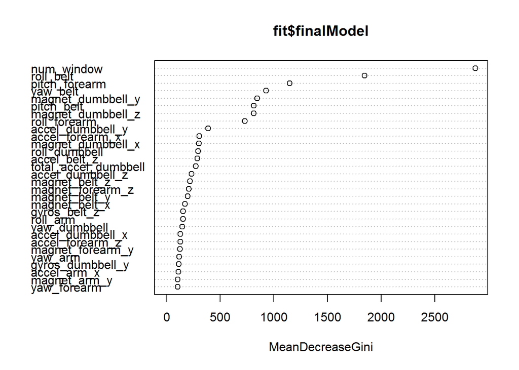

```r
varImpPlot(fit$finalModel)
```

The OOB estimate of error rate is quite low at 0.14%. Considering the class error rates on the right most column being such low number, it appears that the model is a good fit. For that low an OOB, i would expect a 99.8% accuracy in the prediction results.

**Testing Model with the test set**

In order to run against the test set, since we had hour of the day as a factor in training as opposed to actual time stamps, we factorize that predictor as in training before running the predict call. The run of the fit model against the test set gave 20/20 correct answers.

```r
test$cvtd_timestamp = strptime(test$cvtd_timestamp, '%d/%m/%Y %H:%M')
test$cvtd_timestamp = hour(test$cvtd_timestamp)
test$cvtd_timestamp = as.factor(test$cvtd_timestamp)
pred = predict(fit, test)
pred
```

```
##  [1] B A B A A E D B A A B C B A E E A B B B
## Levels: A B C D E
```

I am more than happy with this result even if i didnt have the try to tweak/tune the control/grid params for a longer run. It probably is not worth the push as one may only enter the domain of overfitting!